# Impact Of Severe Weather Events On Health & Economy

Aasish Agarwal

Sunday, May 24, 2015

## Synopsis

Storms and other severe weather events can cause both public health and economic problems for communities and municipalities. Many severe events can result in fatalities, injuries, and property damage, and preventing such outcomes to the extent possible is a key concern.

This report presents the results of our analysis to address following questions

- Across the United States, which types of events (as indicated in the `EVTYPE` variable) are most harmful with respect to population health?
- Across the United States, which types of events have the greatest economic consequences?

*NOTE*: We have used U.S. National Oceanic and Atmospheric Administration’s (NOAA) [storm database](https://d396qusza40orc.cloudfront.net/repdata%2Fdata%2FStormData.csv.bz2) for this study. More details about this database are available under Appendix.

## Data Processing

```r
data.frame(Sys.info())
```

```
##                                Sys.info..
## sysname                           Windows
## release                             7 x64
## version        build 7601, Service Pack 1
## nodename                       IONDELLT22
## machine                            x86-64
## login                           A.Agarwal
## user                            A.Agarwal
## effective_user                  A.Agarwal
```

##### Packages Used

```r
library(dplyr)
```

```r
library(ggplot2)
```

##### Downloading and Uncompressing [NOAA storm database](https://d396qusza40orc.cloudfront.net/repdata%2Fdata%2FStormData.csv.bz2)

```r
  url <- "https://d396qusza40orc.cloudfront.net/repdata%2Fdata%2FStormData.csv.bz2"
  # Creating folder named data to download the dataset
  if (! file.exists("data")){
    dir.create("data")
  }
  projectDatafile <- "data/StormData.csv.bz2"

  # Downloadoing data set if not already exists
  if (! file.exists(projectDatafile)){
      download.file(url , projectDatafile, method = "curl")
      cat("Download Complete")
  } else {
    cat("Skipping Download! File Already Available")
  }
```

```
## Skipping Download! File Already Available
```

Downlaoded file is in zipped format having size = 47 MB. So we are loading this in a cached `r-code block`.

```r
paste("Loading Dataset:- ", date())
```

```
## [1] "Loading Dataset:-  Sun May 24 17:46:16 2015"
```

```r
storm_db_full <-read.csv(bzfile(projectDatafile))
paste("Dataset Load Complere:- ", date())
```

```
## [1] "Dataset Load Complere:-  Sun May 24 17:48:58 2015"
```

```r
#storm_db_full <-read.csv("data/a.csv")
```

We need a subset of the existing fields, to address the concerns

```r
names (storm_db_full)
```

```
##  [1] "STATE__"    "BGN_DATE"   "BGN_TIME"   "TIME_ZONE"  "COUNTY"
##  [6] "COUNTYNAME" "STATE"      "EVTYPE"     "BGN_RANGE"  "BGN_AZI"
## [11] "BGN_LOCATI" "END_DATE"   "END_TIME"   "COUNTY_END" "COUNTYENDN"
## [16] "END_RANGE"  "END_AZI"    "END_LOCATI" "LENGTH"     "WIDTH"
## [21] "F"          "MAG"        "FATALITIES" "INJURIES"   "PROPDMG"
## [26] "PROPDMGEXP" "CROPDMG"    "CROPDMGEXP" "WFO"        "STATEOFFIC"
## [31] "ZONENAMES"  "LATITUDE"   "LONGITUDE"  "LATITUDE_E" "LONGITUDE_"
## [36] "REMARKS"    "REFNUM"
```

- EVTYPE - Type Of Event
- FATALITIES - Number of deaths caused
- INJURIES - Number of injuries caused
- PROPDMG - Damages to property
- PROPDMGEXP - Scale Of Damages to property. This is represented in exponentials of 10.
- CROPDMG - Damages to Crops
- CROPDMGEXP - Scale of Damages to Crops. This is represented in exponentials of 10.

PROPDMGEXP & CROPDMGEXP have following values

```r
storm_db <- storm_db_full %>% tbl_df() %>%
  select (EVTYPE, FATALITIES, INJURIES,PROPDMG, PROPDMGEXP, CROPDMG, CROPDMGEXP)

levels(storm_db$PROPDMGEXP)
```

```
##  [1] ""  "-" "?" "+" "0" "1" "2" "3" "4" "5" "6" "7" "8" "B" "h" "H" "K"
## [18] "m" "M"
```

```r
levels(storm_db$CROPDMGEXP)
```

```
## [1] ""  "?" "0" "2" "B" "k" "K" "m" "M"
```

We will now update the exponents to correct values. And calculate damages

```r
storm_db$PROPDMGEXP <- sub("^$|[-?+]", "0",storm_db$PROPDMGEXP)
storm_db$PROPDMGEXP <- sub("[Hh]", "2",storm_db$PROPDMGEXP)
storm_db$PROPDMGEXP <- sub("[Kk]", "3",storm_db$PROPDMGEXP)
storm_db$PROPDMGEXP <- sub("[Mm]", "6",storm_db$PROPDMGEXP)
storm_db$PROPDMGEXP <- sub("[Bb]", "9",storm_db$PROPDMGEXP)

storm_db$CROPDMGEXP <- sub("^$|[-?+]", "0",storm_db$CROPDMGEXP)
storm_db$CROPDMGEXP <- sub("[Hh]", "2",storm_db$CROPDMGEXP)
storm_db$CROPDMGEXP <- sub("[Kk]", "3",storm_db$CROPDMGEXP)
storm_db$CROPDMGEXP <- sub("[Mm]", "6",storm_db$CROPDMGEXP)
storm_db$CROPDMGEXP <- sub("[Bb]", "9",storm_db$CROPDMGEXP)

storm_db <- storm_db %>%
  mutate( PROPDMGEXP = as.numeric(PROPDMGEXP), CROPDMGEXP = as.numeric(CROPDMGEXP)) %>%
  mutate(PROPDMG = PROPDMG * 10^PROPDMGEXP ,  CROPDMG = CROPDMG * 10^CROPDMGEXP) %>%
  group_by(EVTYPE ) %>%
  summarize( FATALITIES = sum(FATALITIES), INJURIES = sum(INJURIES), DAMAGES = sum(PROPDMG) + sum(CROPDMG))
```

Next we will get top 10 events in each category

- Highest Fatalities
- Highest Injuries
- Highest Damages

```r
top_fatalities <- storm_db %>%
  select(EVTYPE, FATALITIES) %>%
  arrange(desc(FATALITIES) ) %>%
  head(10)


top_injuries <- storm_db %>%
  select(EVTYPE, INJURIES) %>%
  arrange(desc(INJURIES) ) %>%
  head(10)

top_damages <- storm_db %>%
  select(EVTYPE, DAMAGES) %>%
  arrange(desc(DAMAGES) ) %>%
  head(10)
```

## Results

- Across the United States, which types of events (as indicated in the `EVTYPE` variable) are most harmful with respect to population health?

#### Maximum Fatalities

```r
top_fatalities
```

```
## Source: local data frame [10 x 2]
##
##            EVTYPE FATALITIES
## 1         TORNADO       5633
## 2  EXCESSIVE HEAT       1903
## 3     FLASH FLOOD        978
## 4            HEAT        937
## 5       LIGHTNING        816
## 6       TSTM WIND        504
## 7           FLOOD        470
## 8     RIP CURRENT        368
## 9       HIGH WIND        248
## 10      AVALANCHE        224
```

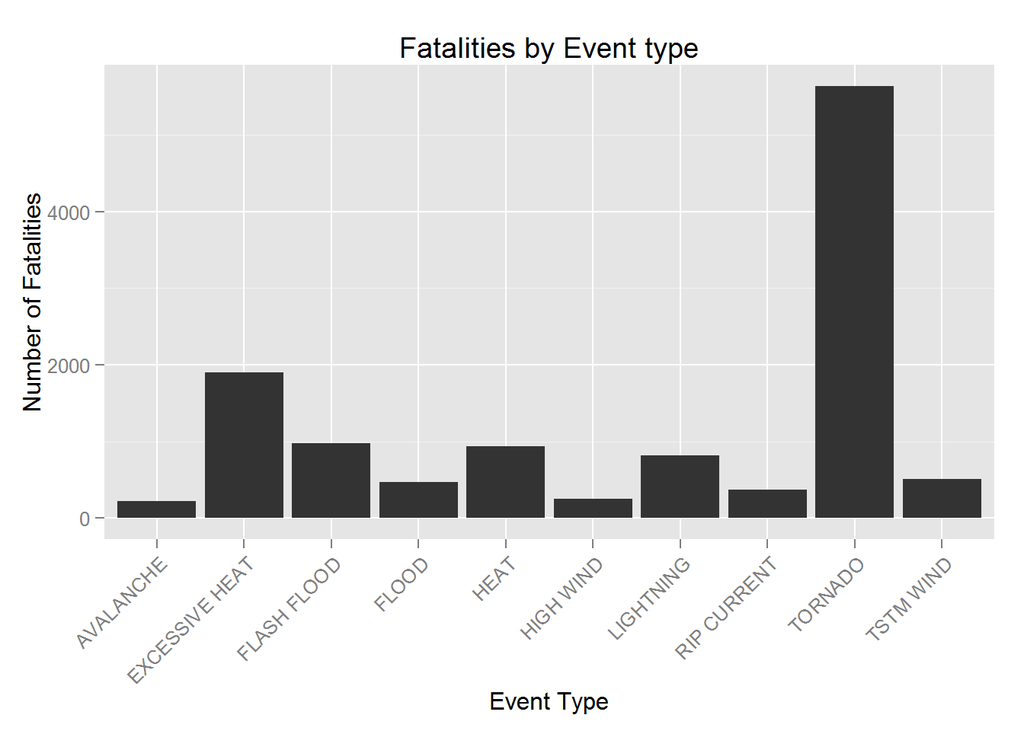

```r
ggplot(top_fatalities, aes(EVTYPE, FATALITIES)) + geom_bar(stat = "identity") +
    xlab("Event Type") + ylab("Number of Fatalities") + ggtitle("Fatalities by Event type")+
    theme(axis.text.x = element_text(angle = 45, hjust=1))
```

#### Maximum Injuries

```r
top_injuries
```

```
## Source: local data frame [10 x 2]
##
##               EVTYPE INJURIES
## 1            TORNADO    91346
## 2          TSTM WIND     6957
## 3              FLOOD     6789
## 4     EXCESSIVE HEAT     6525
## 5          LIGHTNING     5230
## 6               HEAT     2100
## 7          ICE STORM     1975
## 8        FLASH FLOOD     1777
## 9  THUNDERSTORM WIND     1488
## 10              HAIL     1361
```

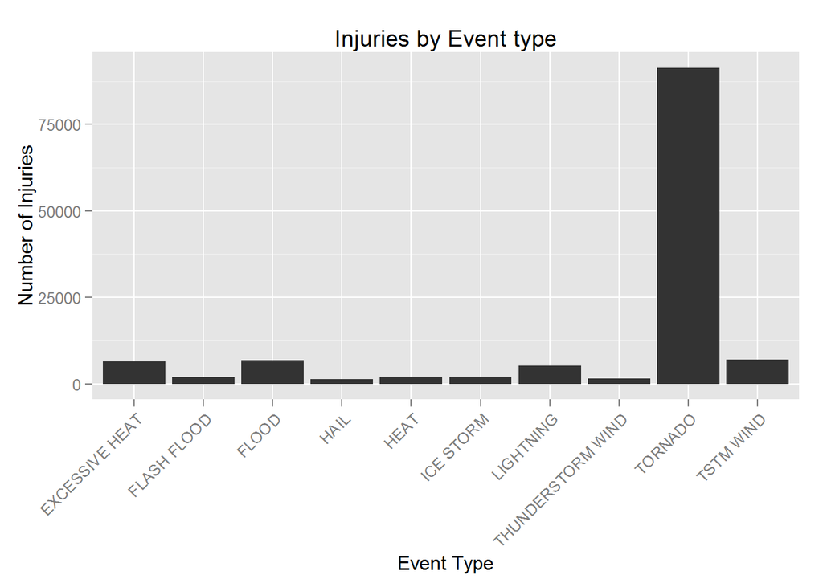

```r
ggplot(top_injuries, aes(EVTYPE, INJURIES)) + geom_bar(stat = "identity") +
    xlab("Event Type") + ylab("Number of Injuries") + ggtitle("Injuries by Event type")+
    theme(axis.text.x = element_text(angle = 45, hjust=1))
```

- Across the United States, which types of events have the greatest economic consequences?

#### Maximum Damages

```r
top_damages
```

```
## Source: local data frame [10 x 2]
##
##               EVTYPE      DAMAGES
## 1              FLOOD 150319678257
## 2  HURRICANE/TYPHOON  71913712800
## 3            TORNADO  57362333947
## 4        STORM SURGE  43323541000
## 5               HAIL  18761221986
## 6        FLASH FLOOD  18243991079
## 7            DROUGHT  15018672000
## 8          HURRICANE  14610229010
## 9        RIVER FLOOD  10148404500
## 10         ICE STORM   8967041360
```

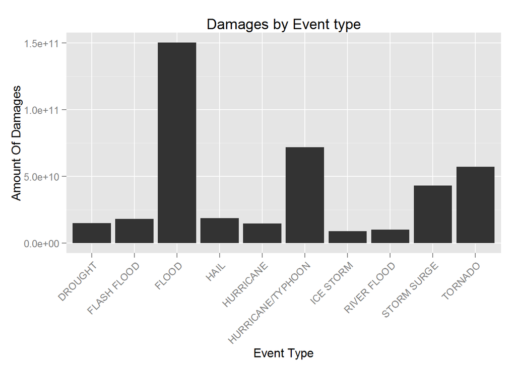

```r
ggplot(top_damages, aes(EVTYPE, DAMAGES)) + geom_bar(stat = "identity") +
    xlab("Event Type") + ylab("Amount Of Damages") + ggtitle("Damages by Event type")+
    theme(axis.text.x = element_text(angle = 45, hjust=1))
```

## Disclaimer

Any decisions made using this report as a reference is the sole responsibility of the reader. Author is not liable for any claims of any concequences of any such actions.

## Appendix

### NOAA Storm Database

This database tracks characteristics of major storms and weather events in the United States, including when and where they occur, as well as estimates of any fatalities, injuries, and property damage.

There is also some documentation of the database available. Here you will find how some of the variables are constructed/defined.

- National Weather Service [Storm Data Documentation](https://d396qusza40orc.cloudfront.net/repdata%2Fpeer2_doc%2Fpd01016005curr.pdf)
- National Climatic Data Center Storm Events [FAQ](https://d396qusza40orc.cloudfront.net/repdata%2Fpeer2_doc%2FNCDC%20Storm%20Events-FAQ%20Page.pdf)

The events in the database start in the year 1950 and end in November 2011. In the earlier years of the database there are generally fewer events recorded, most likely due to a lack of good records. More recent years should be considered more complete.